# Tarea 4 Genómica Funcional 2025

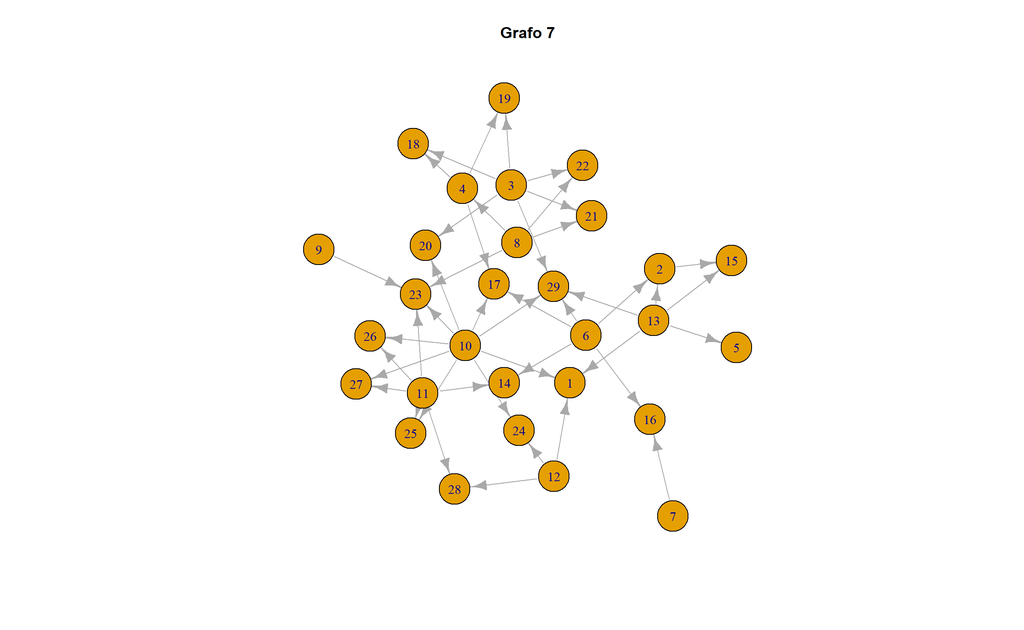

```r
plot(biolog, layout = layout_with_lgl, main = "Grafo 7") # Algoritmo para grafos grandes
```

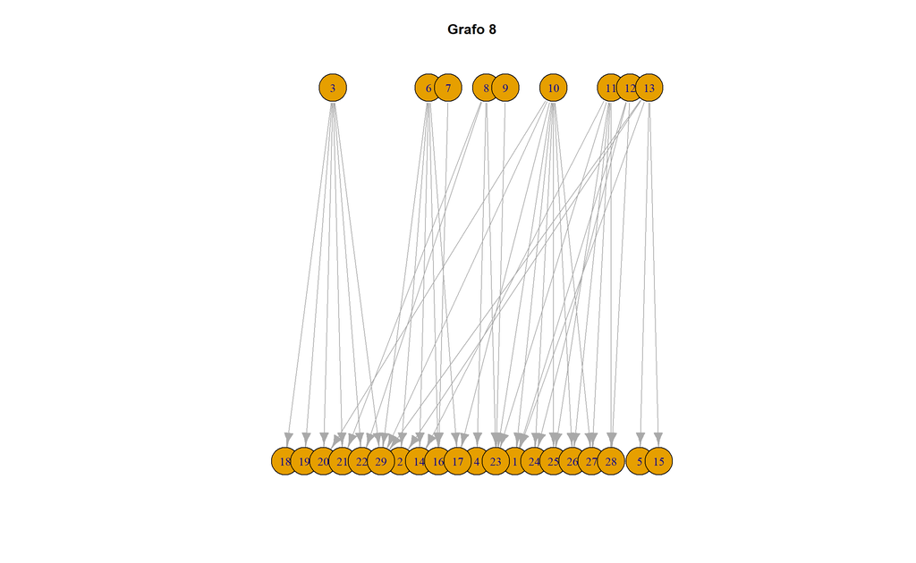

```r
plot(biolog, layout = layout_as_tree, main = "Grafo 8") # Diseño de árbol de Reingold-Tilford
```

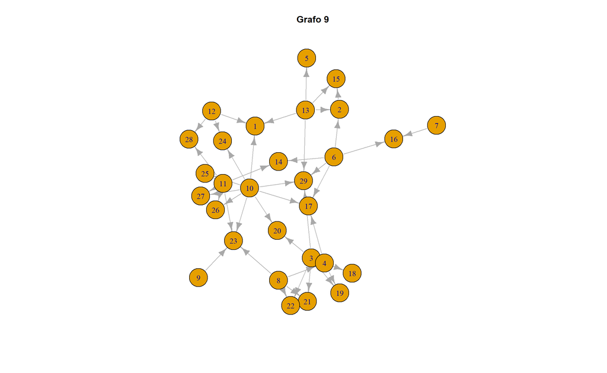

```r
plot(biolog, layout = layout_nicely, main = "Grafo 9") # Diseño de acuerdo a las propiedades de la red.
```

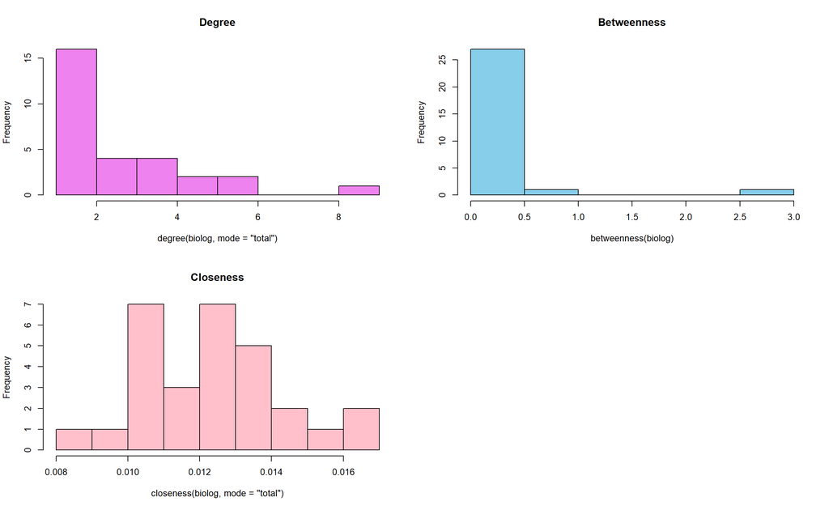

```r
# Medidas de centralidad: medidas de la importancia de un nodo en una red
# Grafica
par(mfrow = c(2, 2))
hist(degree(biolog, mode = "total"), breaks=10, col="violet", main="Degree")
hist(betweenness(biolog), breaks=10, col="skyblue", main="Betweenness")
hist(closeness(biolog, mode = "total"), breaks=10, col="pink", main="Closeness")
```

```r
# Clusterizacion
a <- transitivity(biolog, type = "global") # Global
a
```

```
## [1] 0.02222222
```

```r
b <- transitivity(biolog, type = "local" ) # Local
b
```

```
##  [1] 0.0000000 0.3333333 0.0000000 0.0000000       NaN 0.0000000       NaN
##  [8] 0.0000000       NaN 0.0000000 0.0000000 0.0000000 0.1000000 0.0000000
## [15] 1.0000000 0.0000000 0.0000000 0.0000000 0.0000000 0.0000000 0.0000000
## [22] 0.0000000 0.0000000 0.0000000 0.0000000 0.0000000 0.0000000 0.0000000
## [29] 0.0000000
```

```r
c <- transitivity(biolog, type = "undirected") # Undirected
c
```

```
## [1] 0.02222222
```

5. **Red de coexpresión simulada**

Simula una matriz de expresión con 20 genes en 6 condiciones diferentes.

```r
expresion <- matrix(nrow = 20, ncol = 6) # Matriz vacia
for (x in 1:20) { # Llenar matriz
  expresion[x,] <- cbind(c(sample(1:10, 6, replace = TRUE)))
}
colnames(expresion) <- c("T1", "T2", "T3", "T4", "T5", "T6")
rownames(expresion) <- c(1:20)
expresion
```

```
##    T1 T2 T3 T4 T5 T6
## 1   8  5 10  3  8  2
## 2   5 10  1  1  9  3
## 3   3  8 10  6  1  7
## 4   2  5  3  8  6  1
## 5   1  3 10  2  8  6
## 6   2  8  6  4  1  3
## 7   1  3  2  8  2  2
## 8   8  1 10  6 10  1
## 9   5  9  2  2  9  9
## 10  9  7  8  9  9  2
## 11  2 10  4  5  8  4
## 12  6  6  3  5  3  5
## 13  5  8  3  8  9  5
## 14  2  5  8  7  5  2
## 15  8 10  7  1  1  3
## 16 10  2  5  6  2  7
## 17  4 10  2  3  7  1
## 18  1  5  6  2  3  9
## 19  3 10  7  9  3  6
## 20  5  9  4  5 10  9
```

- Calcula la correlación entre todos los pares de genes
- Construye una red de coexpresión utilizando un umbral de correlación > 0.8.
- Calcula la distribución de grados.
- Identifica si hay módulos o agrupamientos de genes altamente correlacionados.
- Visualiza la red y discute qué tipo de topología tiene.

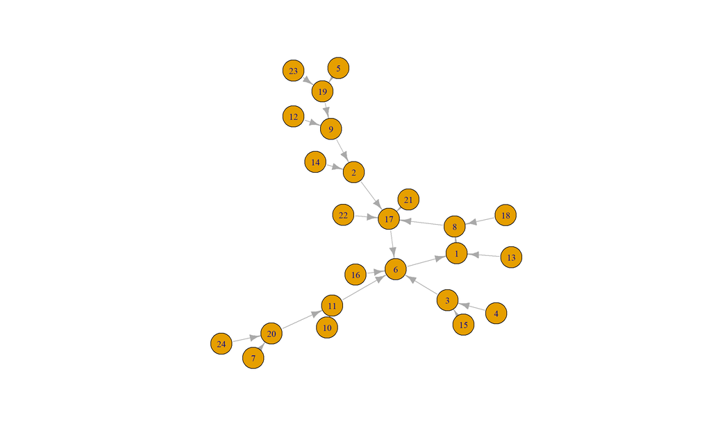

```r
mat_cor <- as.matrix(cor(t(expresion))) # Correlacion entre par de genes
diag(mat_cor)<-0 # Quitar los pares de un gen

c8 <- which(mat_cor > 0.8, arr.ind = TRUE) # Par de genes
# Basado en https://github.com/jumanbar/Curso-R/blob/master/lecciones/manipular-tablas.R

red_c8 <- graph.adjlist(c8)
plot(red_c8)
```

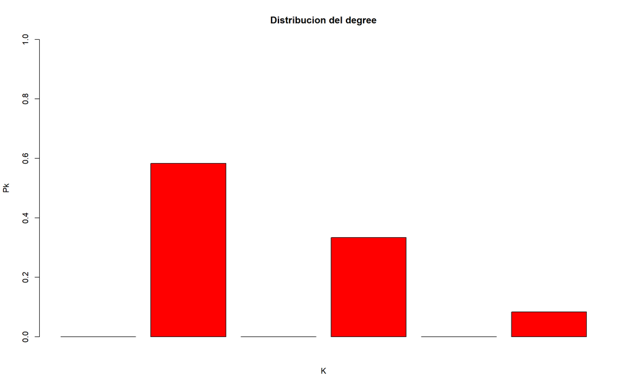

```r
dd_genes <- degree_distribution(red_c8) # Degree distribution
barplot(dd_genes, main='Distribucion del degree', ylim = c(0:1), col='red', ylab = "Pk", xlab = "K")
```

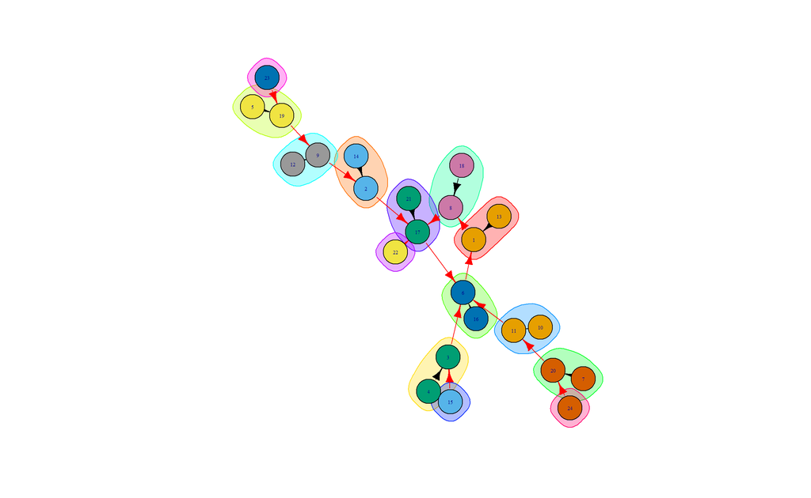

```r
grupos <- cluster_label_prop(red_c8) # Detectar y visualizar grupos
plot(grupos, red_c8,vertex.label.cex=.5)
```

6. **Comparación de redes**

Construye dos redes: - Una red aleatoria tipo Erdos-Rényi. - Una red tipo “scale-free” usando el modelo Barabási–Albert.

Para ambas redes: - Compara su grado promedio, distribución de grados, coeficiente de clusterización y diámetro.

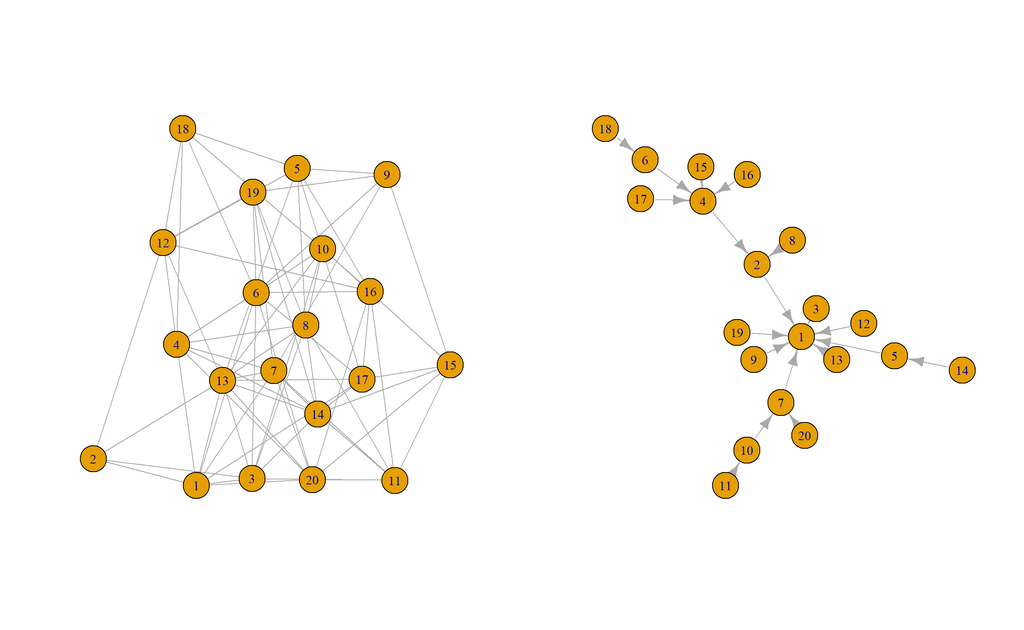

```r
erdos <- sample_gnp(20, 0.4)
barabasi <- sample_pa(20)

# Redes
par(mfrow = c(1, 2))
plot(erdos)
plot(barabasi)
```

```r
# Degree promedio
print(paste("El promedo de la red1 es:", mean(degree(erdos)), "y el de la red2 es: ", mean(degree(barabasi))))
```

```
## [1] "El promedo de la red1 es: 7.4 y el de la red2 es:  1.9"
```

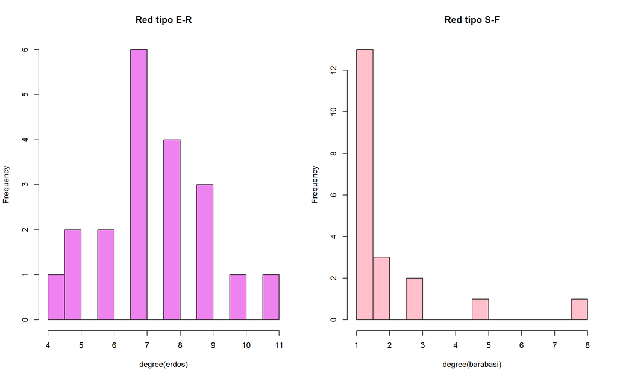

```r
#Distribucion del degree
par(mfrow = c(1, 2))
hist(degree(erdos), breaks=10, col="violet", main="Red tipo E-R")
hist(degree(barabasi), breaks=10, col="pink", main= "Red tipo S-F")
```

```r
# Coeficientes de clusterizacion
cat("\nCC local de la red tipo E-R:", "\n")
```

```
##
## CC local de la red tipo E-R:
```

```r
transitivity(erdos, type = "local") # CC local
```

```
##  [1] 0.5000000 0.6666667 0.4444444 0.3214286 0.2857143 0.2888889 0.3928571
##  [8] 0.3571429 0.2000000 0.2857143 0.4285714 0.2380952 0.3454545 0.3888889
## [15] 0.2000000 0.2857143 0.3333333 0.4000000 0.2666667 0.4166667
```

```r
cat("\nCC global de la red tipo E-R:", transitivity(erdos, type = "global" ), "\n") # CC global
```

```
##
## CC global de la red tipo E-R: 0.3525896
```

```r
cat("\nCC local de la red tipo S-F:", "\n")
```

```
##
## CC local de la red tipo S-F:
```

```r
transitivity(barabasi, type = "local") # CC local
```

```
##  [1]   0   0 NaN   0   0   0   0 NaN NaN   0 NaN NaN NaN NaN NaN NaN NaN NaN NaN
## [20] NaN
```

```r
cat("\nCC global de la red tipo S-F:", transitivity(barabasi, type = "global" ), "\n") # CC global
```

```
##
## CC global de la red tipo S-F: 0
```

```r
# Diametro / camino más largo
print(paste("El diametro de la red1 es:", diameter(erdos), "y el de la red2 es: ", diameter(barabasi)))
```

```
## [1] "El diametro de la red1 es: 3 y el de la red2 es:  4"
```

- Interpreta las diferencias en el contexto de redes biológicas.

Lo que se puede observar entre ambas redes es que la de tipo S-F presenta un numero promedio de conexiones menor debido a que la mayoría de nodos tienen muy bajas conexiones y son pocos los que tienen muchas. En la red E-R la mayoría de los nodos presentan una gran cantidad de conexiones con diferentes nodos, es decir, que hay una cantidad de conexiones similares para cada nodo.  
En el caso de la red S-F la transitividad es de 0 mientras que en la red E-R es >0; lo que se debe a la baja conectividad que existe entre los nodos de la red de tipo S-F donde los puntos de mayor conexión son considerados hubs y sitios críticos/importantes en este tipo de matrices, en donde la eliminación de ese nodo central podría llevar a la fragmentación y/o deformación de la estructura de la red debido a la pérdida de un gran número de conexiones. De manera general, lo que se ve es que la red E-R es más robusta que la S-F ya que la eliminación de nodos, independientemente si es dirigida o al azar, terminaría por no tener un impacto significativo en cuanto a las conexiones entre los demás nodos y la estructura general de la red.